# Workshop 1

Callum Abbott

02/10/2020

# Problem 3

In this exercise we will simulate data and investigate the impact of different mechanisms of missingness.

Consider $Y = (Y1, Y2, Y3)$, to be simulated from a standard trivariate normal distribution with correlations $\rho_{1,2}$, $\rho_{1,3}$ and $\rho_{2,3}$ all equal to 0.5.

Missingness will then be imposed on $Y2$, while $Y1$ and $Y3$ remain fully observed. Additionally, let $R$ be the missingness indicator, taking the value 1 for observed values and 0 for missing values. In the following consider $n = 500$.

```r
set.seed(42)
require(MASS)

# Set parameters given by question.
n <- 500;
mu1 <- mu2 <- mu3 <- 0;
sigma1 <- sigma2 <- sigma3 <- 1;
rho <- 0.5

# Form the covariance matrix
Sigma = matrix(
  c(sigma1^2, rho*sigma1*sigma2, rho*sigma1*sigma3,
    rho*sigma2*sigma1, sigma2^2, rho*sigma2*sigma3,
    rho*sigma3*sigma1, rho*sigma3*sigma2, sigma3^2),
    nrow=3, ncol=3, byrow=TRUE)

# Sample from multivariate Gaussian.
Y <- mvrnorm(n=n, mu=c(mu1, mu2, mu3), Sigma=Sigma)

# Look at first 10 rows of dataset.
Y[1:10,]
```

```
##             [,1]       [,2]       [,3]
##  [1,]  0.2229903 -2.3051398 -1.2759991
##  [2,]  0.7636762 -0.1476143  0.7671605
##  [3,]  0.2639601 -0.5754916 -0.5779478
##  [4,] -0.2990845 -0.6935578 -0.5575482
##  [5,] -0.9050861  0.3174943 -0.4026593
##  [6,] -0.2583066  0.3581909  0.1600666
##  [7,] -1.1387446 -0.7672521 -1.7964609
##  [8,] -1.6134683  1.4061453  0.4391894
##  [9,] -2.1375796 -0.7928578 -2.0136709
## [10,]  0.5122688 -0.5974295  0.2387782
```

```r
# Storing and rounding the simulated values in three variables
Y1 <- Y[,1]; Y2 <- Y[,2]; Y3 <- Y[,3]
```

## Exercise 3a

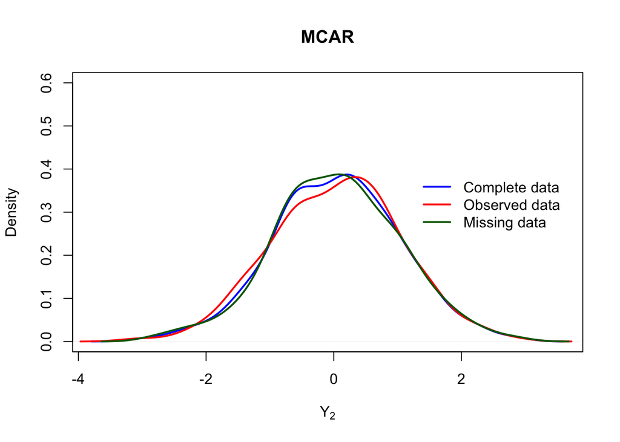

```r
theta <- 0.35
r_mcar <- rbinom(n, size=1, prob=theta)
# Indices of observed variables
ind_mcar_obs <- which(r_mcar == 1)
# Extract missing and observed values from Y2
Y2_mcar_obs <- Y2[ind_mcar_obs]
Y2_mcar_mis <- Y2[-ind_mcar_obs]
# Plotting.
plot(density(Y2), lwd = 2, col = "blue", xlab = expression(Y[2]), main = "MCAR", ylim = c(0, 0.6))
lines(density(Y2_mcar_obs), lwd = 2, col = "red")
lines(density(Y2_mcar_mis), lwd = 2, col = "darkgreen")
legend(1.2, 0.4, legend = c("Complete data", "Observed data", "Missing data"),
       col = c("blue", "red", "darkgreen"), lty = c(1,1,1), lwd = c(2,2,2), bty ="n")
```

We see that the distributions of complete, observed and missing data are all very similar; a trademark indicator that the data is MCAR.

We can visualise this another way using boxplots for which we also expect to see similar distributions.

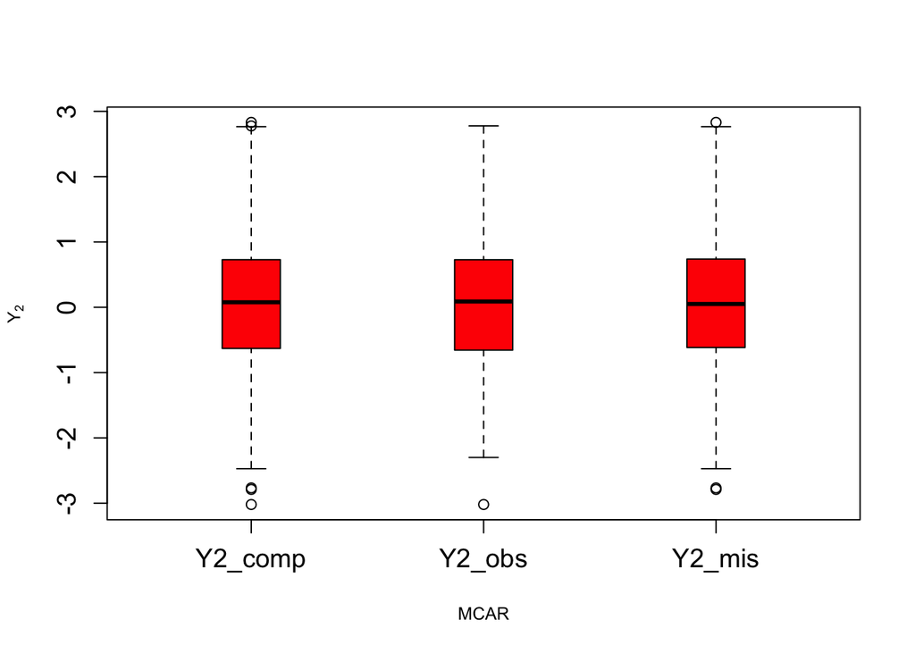

```r
# Get number of observed and missing variables.
n_obs <- length(Y2_mcar_obs)
n_mis <- length(Y2_mcar_mis)
index <- rep("Y2_comp", n + n_obs + n_mis)
index[(n+1):(n+n_obs)] <- "Y2_obs"
index[(n+n_obs+1):(n+n_obs+n_mis)] <- "Y2_mis"
index1 <- factor(index, levels = c("Y2_comp","Y2_obs","Y2_mis"))
Y2boxmcar <- c(Y2, Y2_mcar_obs,Y2_mcar_mis)
boxplot(Y2boxmcar ~ index1, boxwex = 0.25, col = "red", cex.lab = 0.8,
        cex.axis = 1.2, ylab = expression(Y[2]), xlab ="MCAR")
```

## Exercise 3b

We repeat the above procedure for exercise 3b, however, this time we impose the MAR missing data mechanism by considering the following: $Pr(R=0|Y_1, Y_2, Y_3,\beta) = \frac{e^{\beta_0 + \beta_1Y_3}}{1 + e^{\beta_0 + \beta_1Y_3}}$.

Note that for the prob argument of the rbinom function we use the compliment of the model listed previously. This is because $R=1$ indicates an observed value meanwhile $R=0$ indicates a missing value.

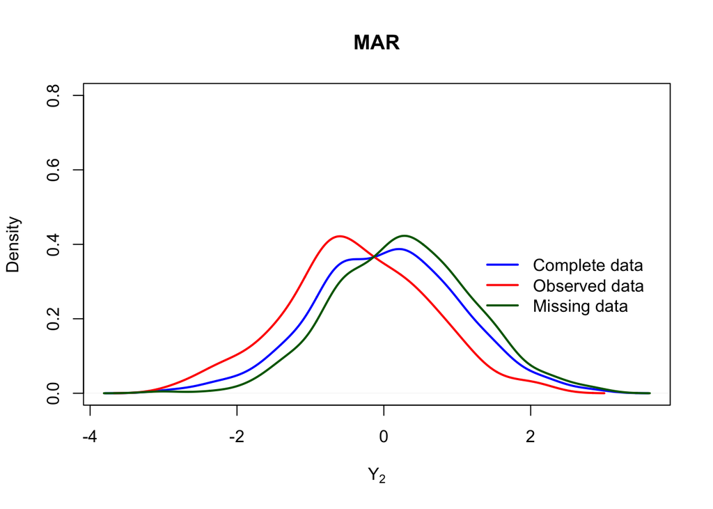

```r
beta0 <- 1.5; beta1 <- 3;
r_mar <- rbinom(n, size=1, prob=1/(1+exp(beta0+beta1*Y3)))
ind_mar_obs <- which(r_mar==1)
Y2_mar_obs <- Y2[ind_mar_obs]
Y2_mar_mis <- Y2[-ind_mar_obs]
# Plotting.
plot(density(Y2), lwd = 2, col = "blue", xlab = expression(Y[2]), main = "MAR", ylim = c(0, 0.8))
lines(density(Y2_mar_obs), lwd = 2, col = "red")
lines(density(Y2_mar_mis), lwd = 2, col = "darkgreen")
legend(1.2, 0.4, legend = c("Complete data", "Observed data", "Missing data"),
       col = c("blue", "red", "darkgreen"), lty = c(1,1,1), lwd = c(2,2,2), bty ="n")
```

We now observe that the distributions for each condition are starting to diverge. We expect this due to the face that our missing data mechansism is only dependent on variables that have been fully observed which suggest that the missing data will be MAR.

## Exercise 3c

Finally, we consider the MNAR case where our missing data mechnism takes the following form: $Pr(R=0|Y_1, Y_2, Y_3,\beta) = \frac{e^{\beta_0 + \beta_1Y_1 + \beta_2Y_2}}{1 + e^{\beta_0 + \beta_1Y_1 + \beta_2Y_2}}$.

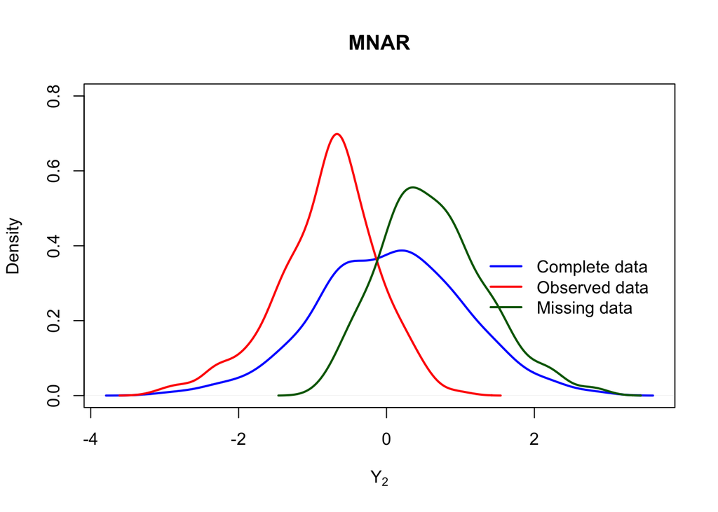

```r
beta0 <- 1.5; beta1 <- 3; beta2 = 5;
r_mnar <- rbinom(n, size=1, prob=1/(1+exp(beta0+beta1*Y1+beta2*Y2)))
ind_mnar_obs <- which(r_mnar==1)
Y2_mnar_obs <- Y2[ind_mnar_obs]
Y2_mnar_mis <- Y2[-ind_mnar_obs]
# Plotting.
plot(density(Y2), lwd = 2, col = "blue", xlab = expression(Y[2]), main = "MNAR", ylim = c(0, 0.8))
lines(density(Y2_mnar_obs), lwd = 2, col = "red")
lines(density(Y2_mnar_mis), lwd = 2, col = "darkgreen")
legend(1.2, 0.4, legend = c("Complete data", "Observed data", "Missing data"),
       col = c("blue", "red", "darkgreen"), lty = c(1,1,1), lwd = c(2,2,2), bty ="n")
```

And as expected, we see the greatest disparity between the 3 distributions for the MNAR situation.